# IPLGGPlot - project 2

SKoka

6/24/2019

Introduction:

IPL - The Indian Premier League (IPL) is a professional Twenty20 cricket league in India contested during March or April and May of every year by eight teams representing eight different cities in India. In project 1, we implemented data cleaning process of the IPL data set which picked up from the kaggle website In project2, we will implementing the statistical inference of the IPL dataset byy using the ggplot - geom_bar(), geom_dotplot() and geom_point() Below we will be covering, 1. Number of times each team won the toss 2. Number of games played in each city 3. Number of games won by each team 4. Percentage of each teams winning 5. Each teams won by runs for all the games

```r
matches <- read.csv("matches.csv")
```

```r
View(matches)
```

```r
library(ggplot2)
library(dplyr)
library(tidyr)
```

# GGPlots

## 1. Number of times each team won the toss

### Prepare the data - filter na toss win games

```r
nonNullTWMatches <- matches[which(!is.na(matches$toss_winner)),]
nonNullTWMatches
```

```
##      id season           city       date                       team1
## 1     1   2017      Hyderabad 2017-04-05         Sunrisers Hyderabad
## 2     2   2017           Pune 2017-04-06              Mumbai Indians
## 3     3   2017         Rajkot 2017-04-07               Gujarat Lions
## 4     4   2017         Indore 2017-04-08      Rising Pune Supergiant
## 5     5   2017      Bangalore 2017-04-08 Royal Challengers Bangalore
## 6     6   2017      Hyderabad 2017-04-09               Gujarat Lions
## 7     7   2017         Mumbai 2017-04-09       Kolkata Knight Riders
## 8     8   2017         Indore 2017-04-10 Royal Challengers Bangalore
## 9     9   2017           Pune 2017-04-11            Delhi Daredevils
## 10   10   2017         Mumbai 2017-04-12         Sunrisers Hyderabad
## 11   11   2017        Kolkata 2017-04-13             Kings XI Punjab
## 12   12   2017      Bangalore 2017-04-14 Royal Challengers Bangalore
## 13   13   2017         Rajkot 2017-04-14      Rising Pune Supergiant
## 14   14   2017        Kolkata 2017-04-15       Kolkata Knight Riders
```

[output cut: 3807 more lines]

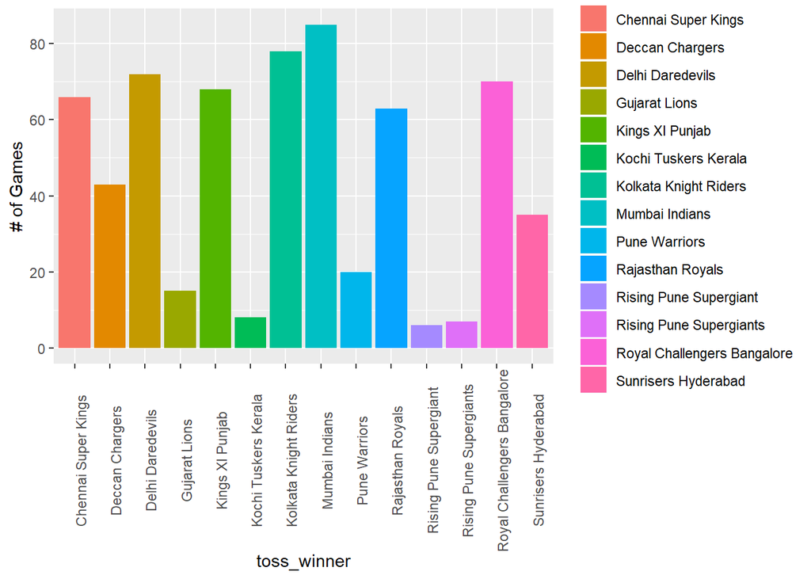

```r
ggplot(nonNullTWMatches,aes(toss_winner,fill= toss_winner)) +geom_bar() + theme(axis.text.x = element_text(angle = 90))+ ylab("# of Games")
```

## Number of games played in each city ### Prepare the data - filter na city games

```r
nonNullCityMatches <- matches[which(!is.na(matches$city)),]
nonNullCityMatches
```

```
##      id season           city       date                       team1
## 1     1   2017      Hyderabad 2017-04-05         Sunrisers Hyderabad
## 2     2   2017           Pune 2017-04-06              Mumbai Indians
## 3     3   2017         Rajkot 2017-04-07               Gujarat Lions
## 4     4   2017         Indore 2017-04-08      Rising Pune Supergiant
## 5     5   2017      Bangalore 2017-04-08 Royal Challengers Bangalore
## 6     6   2017      Hyderabad 2017-04-09               Gujarat Lions
## 7     7   2017         Mumbai 2017-04-09       Kolkata Knight Riders
## 8     8   2017         Indore 2017-04-10 Royal Challengers Bangalore
## 9     9   2017           Pune 2017-04-11            Delhi Daredevils
## 10   10   2017         Mumbai 2017-04-12         Sunrisers Hyderabad
## 11   11   2017        Kolkata 2017-04-13             Kings XI Punjab
## 12   12   2017      Bangalore 2017-04-14 Royal Challengers Bangalore
## 13   13   2017         Rajkot 2017-04-14      Rising Pune Supergiant
## 14   14   2017        Kolkata 2017-04-15       Kolkata Knight Riders
```

[output cut: 3807 more lines]

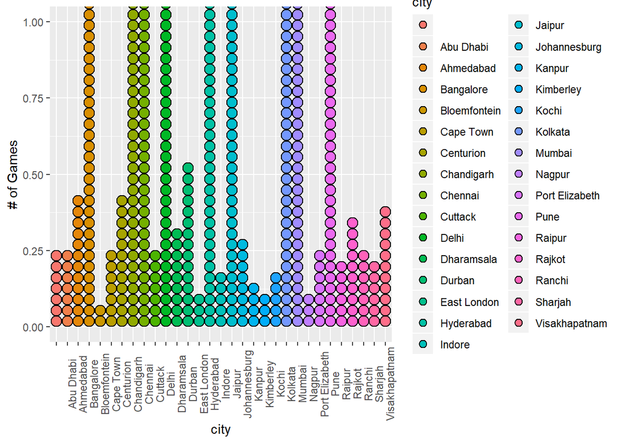

```r
ggplot(nonNullCityMatches,aes(city,fill= city)) +geom_dotplot() + theme(axis.text.x = element_text(angle = 90))+ ylab("# of Games")
```

## Count of win games

### Prepare the data - filter na and tie result games

```r
wonMatches <- matches[matches$result=="normal",]
wonMatches
```

```
##      id season           city       date                       team1
## 1     1   2017      Hyderabad 2017-04-05         Sunrisers Hyderabad
## 2     2   2017           Pune 2017-04-06              Mumbai Indians
## 3     3   2017         Rajkot 2017-04-07               Gujarat Lions
## 4     4   2017         Indore 2017-04-08      Rising Pune Supergiant
## 5     5   2017      Bangalore 2017-04-08 Royal Challengers Bangalore
## 6     6   2017      Hyderabad 2017-04-09               Gujarat Lions
## 7     7   2017         Mumbai 2017-04-09       Kolkata Knight Riders
## 8     8   2017         Indore 2017-04-10 Royal Challengers Bangalore
## 9     9   2017           Pune 2017-04-11            Delhi Daredevils
## 10   10   2017         Mumbai 2017-04-12         Sunrisers Hyderabad
## 11   11   2017        Kolkata 2017-04-13             Kings XI Punjab
## 12   12   2017      Bangalore 2017-04-14 Royal Challengers Bangalore
## 13   13   2017         Rajkot 2017-04-14      Rising Pune Supergiant
## 14   14   2017        Kolkata 2017-04-15       Kolkata Knight Riders
```

[output cut: 3747 more lines]

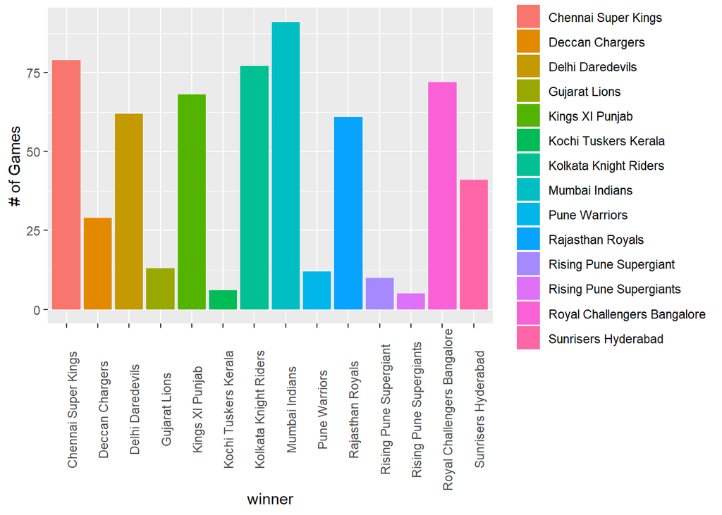

```r
ggplot(wonMatches,aes(winner,fill= winner)) +geom_bar() + theme(axis.text.x = element_text(angle = 90))+ ylab("# of Games")
```

## ggplot of winning percentage ### Prepare the data - collect the number matches as team 1

```r
asT1<- table(matches$team1)
asT1
```

```
##
##         Chennai Super Kings             Deccan Chargers
##                          77                          43
##            Delhi Daredevils               Gujarat Lions
##                          63                          14
##             Kings XI Punjab        Kochi Tuskers Kerala
##                          77                           7
##       Kolkata Knight Riders              Mumbai Indians
##                          68                          82
##               Pune Warriors            Rajasthan Royals
##                          20                          54
##      Rising Pune Supergiant     Rising Pune Supergiants
##                           8                           7
## Royal Challengers Bangalore         Sunrisers Hyderabad
##                          70                          46
```

### Prepare the data - collect the number matches as team 2

```r
asT2<- table(matches$team2)
asT2
```

```
##
##         Chennai Super Kings             Deccan Chargers
##                          54                          32
##            Delhi Daredevils               Gujarat Lions
##                          84                          16
##             Kings XI Punjab        Kochi Tuskers Kerala
##                          71                           7
##       Kolkata Knight Riders              Mumbai Indians
##                          80                          75
##               Pune Warriors            Rajasthan Royals
##                          26                          64
##      Rising Pune Supergiant     Rising Pune Supergiants
##                           8                           7
## Royal Challengers Bangalore         Sunrisers Hyderabad
##                          82                          30
```

# Summ of team1 and team2

```r
consolidatedT <- asT1 + asT2
consolidatedT
```

```
##
##         Chennai Super Kings             Deccan Chargers
##                         131                          75
##            Delhi Daredevils               Gujarat Lions
##                         147                          30
##             Kings XI Punjab        Kochi Tuskers Kerala
##                         148                          14
##       Kolkata Knight Riders              Mumbai Indians
##                         148                         157
##               Pune Warriors            Rajasthan Royals
##                          46                         118
##      Rising Pune Supergiant     Rising Pune Supergiants
##                          16                          14
## Royal Challengers Bangalore         Sunrisers Hyderabad
##                         152                          76
```

### Prepare the data - collect the number matches won by each team

```r
wonMatches <-
wonCount <- table(wonMatches$winner)
wonCount
```

```
##
##                                     Chennai Super Kings
##                           0                          79
##             Deccan Chargers            Delhi Daredevils
##                          29                          62
##               Gujarat Lions             Kings XI Punjab
##                          13                          68
##        Kochi Tuskers Kerala       Kolkata Knight Riders
##                           6                          77
##              Mumbai Indians               Pune Warriors
##                          91                          12
##            Rajasthan Royals      Rising Pune Supergiant
##                          61                          10
##     Rising Pune Supergiants Royal Challengers Bangalore
##                           5                          72
##         Sunrisers Hyderabad
##                          41
```

## Convert into Data frame

```r
matches$winner[matches$winner==""] <- NA
matches
```

```
##      id season           city       date                       team1
## 1     1   2017      Hyderabad 2017-04-05         Sunrisers Hyderabad
## 2     2   2017           Pune 2017-04-06              Mumbai Indians
## 3     3   2017         Rajkot 2017-04-07               Gujarat Lions
## 4     4   2017         Indore 2017-04-08      Rising Pune Supergiant
## 5     5   2017      Bangalore 2017-04-08 Royal Challengers Bangalore
## 6     6   2017      Hyderabad 2017-04-09               Gujarat Lions
## 7     7   2017         Mumbai 2017-04-09       Kolkata Knight Riders
## 8     8   2017         Indore 2017-04-10 Royal Challengers Bangalore
## 9     9   2017           Pune 2017-04-11            Delhi Daredevils
## 10   10   2017         Mumbai 2017-04-12         Sunrisers Hyderabad
## 11   11   2017        Kolkata 2017-04-13             Kings XI Punjab
## 12   12   2017      Bangalore 2017-04-14 Royal Challengers Bangalore
## 13   13   2017         Rajkot 2017-04-14      Rising Pune Supergiant
## 14   14   2017        Kolkata 2017-04-15       Kolkata Knight Riders
```

[output cut: 3807 more lines]

```r
resultG <- matches[which(!is.na(matches$winner)),]
wgames <- matches[matches$result=="normal",]
w <- table(wgames$winner)
gamesW <- data.frame(w)
gamesW$Var1[gamesW$Var1 == ""] <-NA
gamesW
```

```
##                           Var1 Freq
## 1                         <NA>    0
## 2          Chennai Super Kings   79
## 3              Deccan Chargers   29
## 4             Delhi Daredevils   62
## 5                Gujarat Lions   13
## 6              Kings XI Punjab   68
## 7         Kochi Tuskers Kerala    6
## 8        Kolkata Knight Riders   77
## 9               Mumbai Indians   91
## 10               Pune Warriors   12
## 11            Rajasthan Royals   61
## 12      Rising Pune Supergiant   10
## 13     Rising Pune Supergiants    5
## 14 Royal Challengers Bangalore   72
## 15         Sunrisers Hyderabad   41
```

```r
resultCountFinal <- gamesW[which(!is.na(gamesW$Var1)),]
resultCountFinal
```

```
##                           Var1 Freq
## 2          Chennai Super Kings   79
## 3              Deccan Chargers   29
## 4             Delhi Daredevils   62
## 5                Gujarat Lions   13
## 6              Kings XI Punjab   68
## 7         Kochi Tuskers Kerala    6
## 8        Kolkata Knight Riders   77
## 9               Mumbai Indians   91
## 10               Pune Warriors   12
## 11            Rajasthan Royals   61
## 12      Rising Pune Supergiant   10
## 13     Rising Pune Supergiants    5
## 14 Royal Challengers Bangalore   72
## 15         Sunrisers Hyderabad   41
```

```r
resultDF <- data.frame(resultCountFinal)
colnames(resultDF)[1]<-"Team Name"
colnames(resultDF)[2]<-"NumberOfGamesWon"
resultDF
```

```
##                      Team Name NumberOfGamesWon
## 2          Chennai Super Kings               79
## 3              Deccan Chargers               29
## 4             Delhi Daredevils               62
## 5                Gujarat Lions               13
## 6              Kings XI Punjab               68
## 7         Kochi Tuskers Kerala                6
## 8        Kolkata Knight Riders               77
## 9               Mumbai Indians               91
## 10               Pune Warriors               12
## 11            Rajasthan Royals               61
## 12      Rising Pune Supergiant               10
## 13     Rising Pune Supergiants                5
## 14 Royal Challengers Bangalore               72
## 15         Sunrisers Hyderabad               41
```

```r
gamesDF <- data.frame(consolidatedT)
colnames(gamesDF)[1]<-"Team Name"
colnames(gamesDF)[2]<-"NumberOfGames"
gamesDF
```

```
##                      Team Name NumberOfGames
## 1          Chennai Super Kings           131
## 2              Deccan Chargers            75
## 3             Delhi Daredevils           147
## 4                Gujarat Lions            30
## 5              Kings XI Punjab           148
## 6         Kochi Tuskers Kerala            14
## 7        Kolkata Knight Riders           148
## 8               Mumbai Indians           157
## 9                Pune Warriors            46
## 10            Rajasthan Royals           118
## 11      Rising Pune Supergiant            16
## 12     Rising Pune Supergiants            14
## 13 Royal Challengers Bangalore           152
## 14         Sunrisers Hyderabad            76
```

### ggplot of number of games won percentage over number of games played

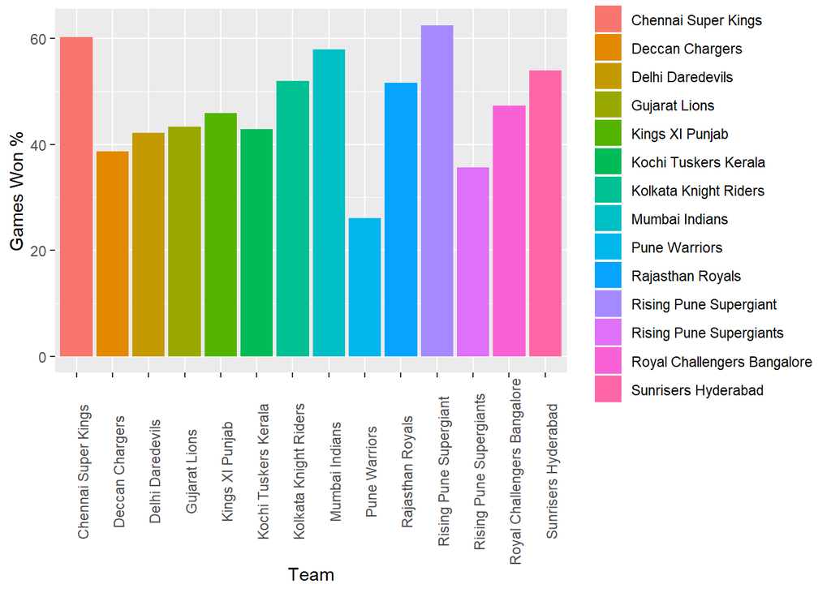

```r
ggplot(left_join(gamesDF,resultDF ),aes(resultDF$`Team Name`,resultDF$NumberOfGamesWon*100/gamesDF$NumberOfGames,fill = resultDF$`Team Name`)) + geom_bar(stat = "identity") + theme(axis.text.x = element_text(angle = 90))+ xlab("Team")+ ylab("Games Won %")
```

```r
wonByRUns <- matches[matches$win_by_runs!=0,]
wonByRUns
```

```
##      id season           city       date                       team1
## 1     1   2017      Hyderabad 2017-04-05         Sunrisers Hyderabad
## 5     5   2017      Bangalore 2017-04-08 Royal Challengers Bangalore
## 9     9   2017           Pune 2017-04-11            Delhi Daredevils
## 14   14   2017        Kolkata 2017-04-15       Kolkata Knight Riders
## 15   15   2017          Delhi 2017-04-15            Delhi Daredevils
## 17   17   2017      Bangalore 2017-04-16      Rising Pune Supergiant
## 19   19   2017      Hyderabad 2017-04-17         Sunrisers Hyderabad
## 20   20   2017         Rajkot 2017-04-18 Royal Challengers Bangalore
## 21   21   2017      Hyderabad 2017-04-19         Sunrisers Hyderabad
## 24   24   2017         Mumbai 2017-04-22              Mumbai Indians
## 26   26   2017         Rajkot 2017-04-23             Kings XI Punjab
## 27   27   2017        Kolkata 2017-04-23       Kolkata Knight Riders
## 28   28   2017         Mumbai 2017-04-24      Rising Pune Supergiant
## 32   32   2017     Chandigarh 2017-04-28         Sunrisers Hyderabad
```

[output cut: 1713 more lines]

##ggplot by using geom_point, which shows each team won by runs for all the games played

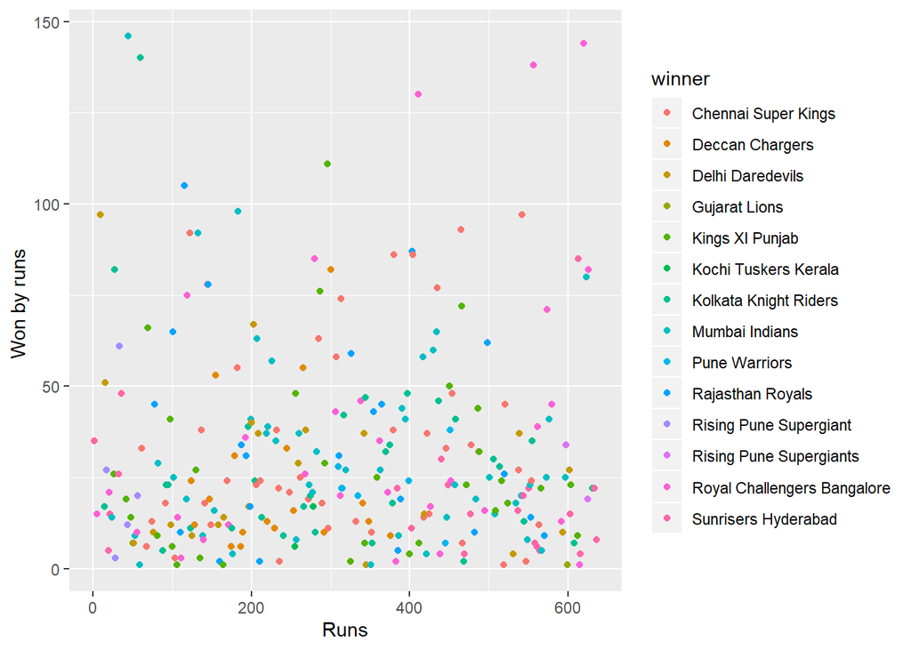

```r
ggplot(matches[matches$win_by_runs!=0,],aes(id,win_by_runs,col= winner )) + geom_point() +
  ylab("Won by runs ") + xlab("Runs")
```